# Markup: Exercise 2

Zoë Dunias

26-10-2020

# 1 Aim

The aim is to verify that for the Poisson distribution $\mu = \lambda$, and to show the relation between skewness and kurtosis and the parameter $\lambda$ using simulation.

# 2 Set up

In this section, the seed is set and the required packages are loaded.

## 2.1 Set random seed

For reproducibility, fix the seed.

```r
set.seed(100)
```

## 2.2 Load packages

```r
library(e1071)
```

# 3 Poisson distribution and its mean

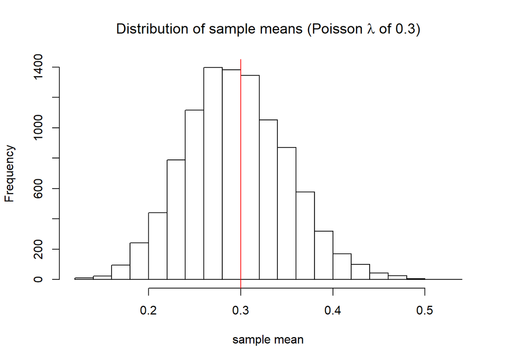

```r
lamb = 0.3

p <- replicate(10000, rpois(n = 100, lambda = lamb))

M <- colMeans(p)

{hist(M,
    main = expression(paste('Distribution of sample means (Poisson ', lambda, ' of 0.3)')),
    xlab = 'sample mean',
    nclass=20)
abline(v = lamb, lty = 1, col = "red") # Add the lambda value to the plot as a red line.
}
```

As expected, the distribution of sample means is centered around the value of $\lambda$.

# 4 Simulate Poisson distributions with varying $\lambda$ values

The (a)symmetry of the Poisson distribution depends on the parameter $\lambda$. As $\lambda$ increases, the Poisson distribution gets more symmetrical. Samples are drawn from Poisson distributions with varying $\lambda$ values.

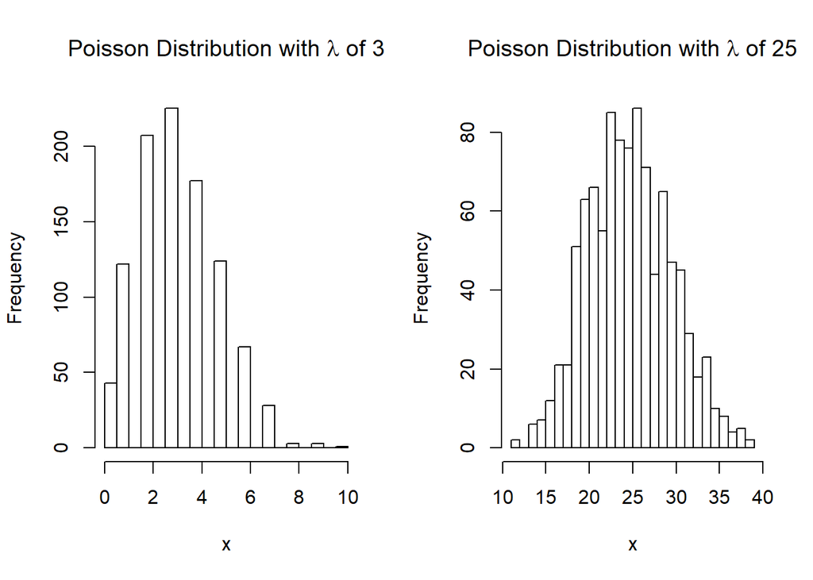

```r
# The logarithmic distribution in the range of lambda's from 0.1 to 30
lamb1 <- seq(log10(0.1), log10(30), 0.1)
lamb2 <- 10^lamb1

# Allocate memory
s <- matrix(0, nrow = 1000, ncol = length(lamb2))

for (i in 1:length(lamb2)) {
  s[,i] <- rpois(n = 1000, lambda = lamb2[i])
}

{par(mfrow=c(1,2))
hist(s[,16],
    main = expression(paste('Poisson Distribution with ', lambda, ' of 3')),
    xlab = 'x',
    nclass=20)
hist(s[,length(lamb2)],
    main = expression(paste('Poisson Distribution with ', lambda, ' of 25')),
    xlab = 'x',
    nclass=20)
}
```

As expected, the distribution of a sample corresponding to $\lambda \approx 3$ is more skewed than the distribution of a sample corresponding to $\lambda \approx 25$.

## 4.1 Skewness and kurtosis

The shape of a distribution can be described with the skewness and kurtosis. For the Poisson distribution, skewness is related to $\lambda$ according to the following:
$$skewness = \frac{1}{\sqrt(\lambda)}$$

For the Poisson distribution, kurtosis is related to $\lambda$ according to the following:
$$kurtosis = \frac{1}{\lambda}$$

The skewness and kurtosis are calculated for the samples with varying $\lambda$ values previously drawn.

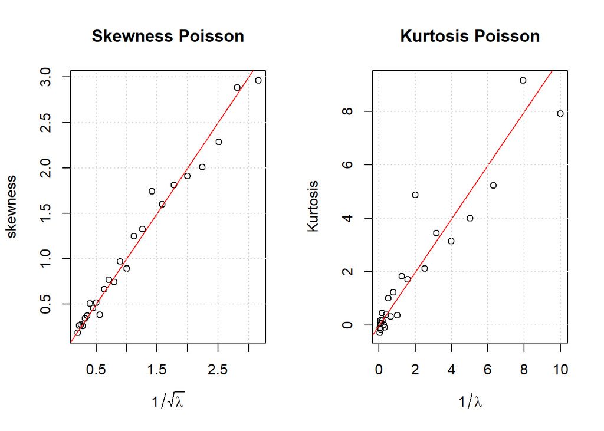

```r
# Allocate memory
skew <- rep(0, length(lamb2))
kurt <- rep(0, length(lamb2))

for (i in 1:length(lamb2)) {
  kurt[i] <- kurtosis(s[,i]) # Calculate kurtosis
  skew[i] <- skewness(s[,i]) # Calculate skewness
}

{par(mfrow=c(1,2))
plot(1/sqrt(lamb2), skew,
    main = 'Skewness Poisson',
    xlab = expression(paste(1/sqrt(lambda))),
    ylab = 'skewness'
    )
abline(0, 1, col = "red")
grid()

plot(1/lamb2, kurt,
    main = 'Kurtosis Poisson',
    xlab = expression(paste(1/lambda)),
    ylab = 'Kurtosis')
abline(0, 1, col = "red")
grid()
}
```

The linear relationships shown, confirm the aforementioned equations.

# 5 Replication

In this section, the results of the study are replicated.

## 5.1 Use a different seed

```r
set.seed(101)
```

## 5.2 Poisson distribution and its mean

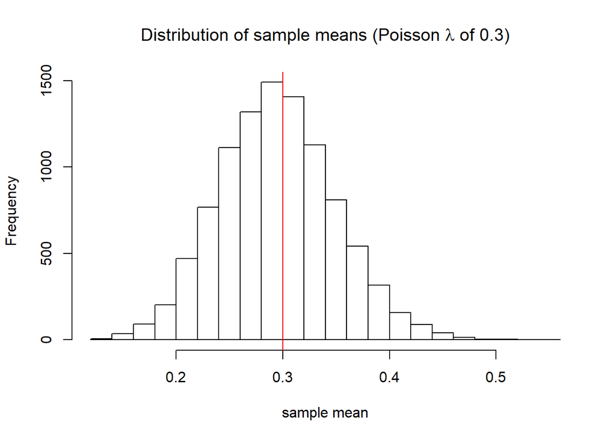

```r
p_rep <- replicate(10000, rpois(n = 100, lambda = lamb))

M_rep <- colMeans(p_rep)

{hist(M_rep,
    main = expression(paste('Distribution of sample means (Poisson ', lambda, ' of 0.3)')),
    xlab = 'sample mean',
    nclass=20)

abline(v = lamb, lty = 1, col = "red") # Add the lambda value to the plot as a red line.
}
```

This results in a slightly different distribution, but the distribution of sample means is again centered around the value of $\lambda$.

## 5.3 Simulate Poisson distributions with varying $\lambda$ values

Again, samples are drawn from Poisson distributions with varying $\lambda$ values.

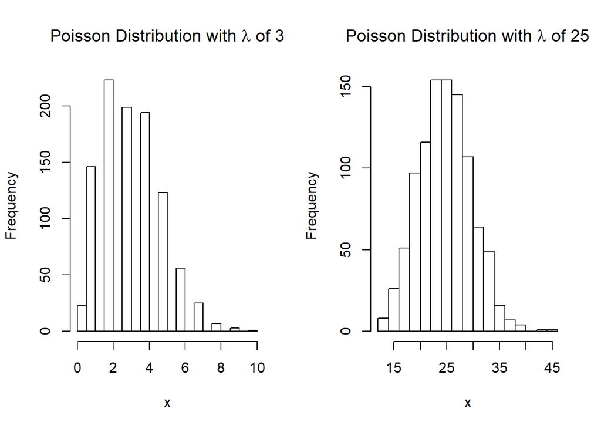

```r
for (i in 1:length(lamb2)) {
  s[,i] <- rpois(n = 1000, lambda = lamb2[i])
}

{par(mfrow=c(1,2))
hist(s[,16],
    main = expression(paste('Poisson Distribution with ', lambda, ' of 3')),
    xlab = 'x',
    nclass=20)
hist(s[,length(lamb2)],
    main = expression(paste('Poisson Distribution with ', lambda, ' of 25')),
    xlab = 'x',
    nclass=20)
}
```

This results in slightly different distributions, but the distribution of a sample corresponding to $\lambda \approx 3$ is again more skewed than the distribution of a sample corresponding to $\lambda \approx 25$.

## 5.4 Skewness and kurtosis

The skewness and kurtosis are calculated for the samples with varying $\lambda$ values previously drawn.

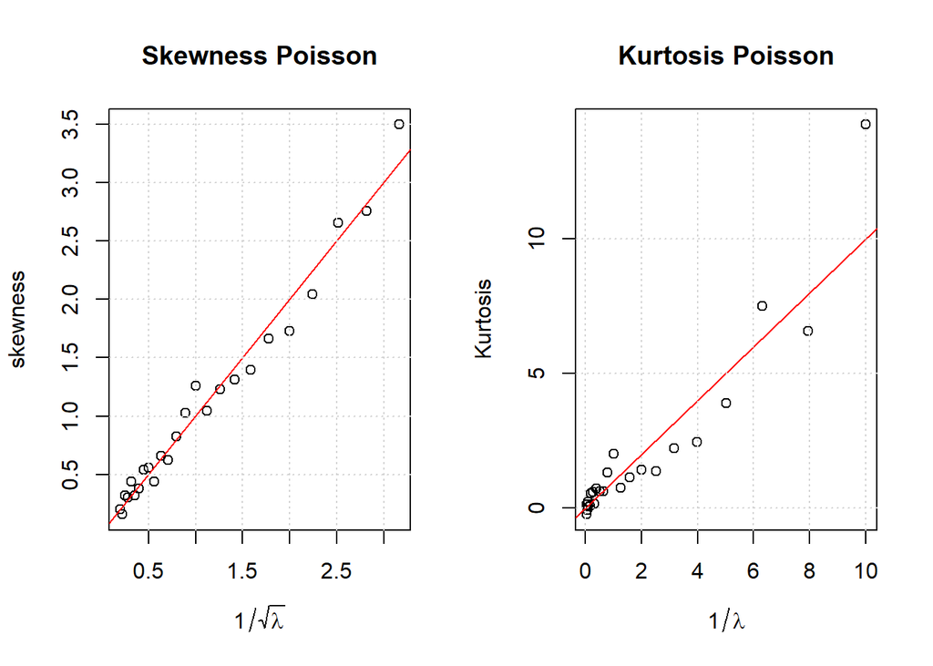

```r
for (i in 1:length(lamb2)) {

  s[,i] <- rpois(n = 1000, lambda = lamb2[i])

  kurt[i] <- kurtosis(s[,i]) # Calculate kurtosis
  skew[i] <- skewness(s[,i]) # Calculate skewness
}

{par(mfrow=c(1,2))
plot(1/sqrt(lamb2), skew,
    main = 'Skewness Poisson',
    xlab = expression(paste(1/sqrt(lambda))),
    ylab = 'skewness'
    )
abline(0, 1, col = "red")
grid()

plot(1/lamb2, kurt,
    main = 'Kurtosis Poisson',
    xlab = expression(paste(1/lambda)),
    ylab = 'Kurtosis')
abline(0, 1, col = "red")
grid()
}
```

This results in slightly different plots (the skewness and kurtosis values are slightly different for the new samples), but again the linear relationships are shown.